# RNA-Seq Analysis Project

Yagmur Yesilyurt - Matriculation number:‘49614A’ - Methods in Bioinformatics Final Project

# 0. Introduction

## 0.1 Project Overview

This RNA-Seq analysis looks at gene expression patterns in human tissues, focusing on finding genes that are uniquely or highly expressed in specific individuals.

## 0.2 Dataset Description

The dataset contains RNA-Seq data from human tissues: - Gene expression counts (28,391 genes × 18 samples) - Multiple tissue types: liver, brain, muscle, heart, kidney, lung - Three donors: S7, S12, S13

### References

- Zambelli et al 2022 (aScan: A Novel Method for the Study of Allele Specific Expression in Single Individuals)
- Picardi et al 2015 (Profiling RNA editing in human tissues: towards the inosinome Atlas)
- D’Erchia et al 2014 (Tissue-specific mtDNA abundance from exome data and its correlation with mitochondrial transcription, mass and respiratory activity)

# 1. Data Processing and Quality Control

## 1.1 Initial Setup

In this section, we will load the necessary libraries and set up the environment for our RNA-Seq analysis.

- **edgeR**: For differential expression analysis
- **ggplot2**: For creating plots and visualizations
- **tidyverse**: For data manipulation and processing
- **stringr**: For handling gene names and text processing

```r
# Load required libraries
library(edgeR)
library(ggplot2)
# library(stringr)

# Create results directory if it doesn't exist
dir.create("../results", showWarnings = TRUE)
```

## 1.2 Data Import and Preprocessing

In this section, we will read the metadata and count data files, check for missing values, and ensure that sample names match between the metadata and count data.

### Load Data

```r
# Read metadata and counts
metadata <- read.csv("../data/Metadata2025.csv", sep = "\t", header = TRUE, check.names = FALSE, row.names = 1)
counts <- read.csv("../data/Counts2025.csv", sep = "\t", header = TRUE, check.names = FALSE, row.names = 1)
```

### Control Data

```r
head(counts) # First few rows
```

```
##           liver_S7 brain_S7 muscle_S7 heart_S7 kidney_S7 lung_S7 liver_S12
## 5S_rRNA          0        0         0        0         0       0         0
## 5_8S_rRNA        0        0         0        0         0       0         0
## 6M1-18           0        0         0        0         0       0         0
## 7M1-2            0        0         0        0         0       0         0
## 7SK           6211     7516      5485     7338     22610   17680      5144
## A1BG         51808       73        14       27        46     121     29836
##           brain_S12 muscle_S12 heart_S12 kidney_S12 lung_S12 liver_S13
## 5S_rRNA           0          0         0          0        0         0
## 5_8S_rRNA         0          0         0          0        0         0
## 6M1-18            0          0         0          0        0         0
## 7M1-2             0          0         0          0        0         0
## 7SK           24682       4877      7683      24804    14654      6647
## A1BG            124         10        12         30       65     35922
##           brain_S13 muscle_S13 heart_S13 kidney_S13 lung_S13
## 5S_rRNA           0          0         0          0        0
## 5_8S_rRNA         0          0         0          0        0
## 6M1-18            0          0         0          0        0
## 7M1-2             0          0         0          0        0
## 7SK           23302       8394      4743      14312    20097
## A1BG            129         27         9         33       95
```

```r
dim(counts) # Should be 28391 genes x 18 samples
```

```
## [1] 28391    18
```

```r
apply(counts, 2, sum) # Total counts per sample
```

```
##   liver_S7   brain_S7  muscle_S7   heart_S7  kidney_S7    lung_S7  liver_S12
##   43216690   29943230   39236182   24899249   24819406   30372887   22662521
##  brain_S12 muscle_S12  heart_S12 kidney_S12   lung_S12  liver_S13  brain_S13
##   37560915   38183550   11435492   25190494   20925870   34942266   38337526
## muscle_S13  heart_S13 kidney_S13   lung_S13
##   56828245   17433479   26302218   29852242
```

```r
sum(is.na(counts)) # Check for missing values
```

```
## [1] 0
```

```r
head(metadata) # First few rows
```

```
##   Tissue Donor
## 1  brain    S7
## 2  brain   S12
## 3  brain   S13
## 4  heart    S7
## 5  heart   S12
## 6  heart   S13
```

```r
dim(metadata) # Should be 18 samples x 2 columns
```

```
## [1] 18  2
```

```r
sum(is.na(metadata)) # Check for missing values
```

```
## [1] 0
```

### Add Sample Column to Metadata

In this step, we will create a new column in the metadata that combines tissue type and donor ID to match the sample names in the count data. This is crucial for ensuring that our metadata aligns with the count data.

```r
metadata$Sample <- paste(metadata$Tissue, metadata$Donor, sep = "_") # Combine Tissue and Donor

columns_name_counts_match_check <- identical(metadata$Sample, colnames(counts)) # Check if sample names match

if (columns_name_counts_match_check == FALSE) { # If names don't match, reorder metadata
    metadata <- metadata[match(colnames(counts), metadata$Sample), ]
    rownames(metadata) <- NULL
    print("Reordered metadata to match count data.")
} else {
    print("Sample names already match.")
}
```

```
## [1] "Reordered metadata to match count data."
```

```r
head(metadata) # Check first few rows of metadata to see the new Sample column
```

```
##   Tissue Donor    Sample
## 1  liver    S7  liver_S7
## 2  brain    S7  brain_S7
## 3 muscle    S7 muscle_S7
## 4  heart    S7  heart_S7
## 5 kidney    S7 kidney_S7
## 6   lung    S7   lung_S7
```

```r
columns_name_counts_match_check <- identical(metadata$Sample, colnames(counts)) # Final check if sample names match

if (columns_name_counts_match_check == FALSE) {
    stop("Sample names still don't match!")
} else {
    print("All good - sample names match.")
}
```

```
## [1] "All good - sample names match."
```

### Create a DGEList object for edgeR analysis

In this step, we will create a `DGEList` object from the count data and metadata. This object is essential for performing differential expression analysis using edgeR.

```r
dge <- DGEList(counts = counts, samples = metadata)
head(dge$counts) # Count matrix
```

```
##           liver_S7 brain_S7 muscle_S7 heart_S7 kidney_S7 lung_S7 liver_S12
## 5S_rRNA          0        0         0        0         0       0         0
## 5_8S_rRNA        0        0         0        0         0       0         0
## 6M1-18           0        0         0        0         0       0         0
## 7M1-2            0        0         0        0         0       0         0
## 7SK           6211     7516      5485     7338     22610   17680      5144
## A1BG         51808       73        14       27        46     121     29836
##           brain_S12 muscle_S12 heart_S12 kidney_S12 lung_S12 liver_S13
## 5S_rRNA           0          0         0          0        0         0
## 5_8S_rRNA         0          0         0          0        0         0
## 6M1-18            0          0         0          0        0         0
## 7M1-2             0          0         0          0        0         0
## 7SK           24682       4877      7683      24804    14654      6647
## A1BG            124         10        12         30       65     35922
##           brain_S13 muscle_S13 heart_S13 kidney_S13 lung_S13
## 5S_rRNA           0          0         0          0        0
## 5_8S_rRNA         0          0         0          0        0
## 6M1-18            0          0         0          0        0
## 7M1-2             0          0         0          0        0
## 7SK           23302       8394      4743      14312    20097
## A1BG            129         27         9         33       95
```

```r
head(dge$samples) # Sample info
```

```
##           group lib.size norm.factors Tissue Donor    Sample
## liver_S7      1 43216690            1  liver    S7  liver_S7
## brain_S7      1 29943230            1  brain    S7  brain_S7
## muscle_S7     1 39236182            1 muscle    S7 muscle_S7
## heart_S7      1 24899249            1  heart    S7  heart_S7
## kidney_S7     1 24819406            1 kidney    S7 kidney_S7
## lung_S7       1 30372887            1   lung    S7   lung_S7
```

# 2. Filtering

In this section, we will filter out lowly expressed genes to focus on those that are more likely to be biologically relevant. We will keep genes that have at least 10 counts in at least one sample.

```r
# Keep genes with at least 10 counts in at least one sample
keep <- rowSums(dge$counts > 10) >= 1
dge <- dge[keep, , keep.lib.sizes = FALSE] # Update DGEList object with filtered counts
print("Dimensions after filtering:")
```

```
## [1] "Dimensions after filtering:"
```

```r
dim(dge)
```

```
## [1] 20653    18
```

# 3. Normalization

In this section, we will normalize the count data to account for differences in library sizes across samples. This is crucial for making fair comparisons between samples.

```r
dge <- calcNormFactors(dge) # Calculate normalization factors using TMM (Trimmed Mean of M-values)

head(dge$samples)
```

```
##           group lib.size norm.factors Tissue Donor    Sample
## liver_S7      1 43215838    0.5237517  liver    S7  liver_S7
## brain_S7      1 29941504    1.3080920  brain    S7  brain_S7
## muscle_S7     1 39235154    0.4490589 muscle    S7 muscle_S7
## heart_S7      1 24898363    0.8709383  heart    S7  heart_S7
## kidney_S7     1 24817867    1.4442236 kidney    S7 kidney_S7
## lung_S7       1 30370842    1.5470616   lung    S7   lung_S7
```

# 4. Multi-dimensional Scaling

In this section, we will perform a multi-dimensional scaling (MDS) analysis to visualize the relationships between samples based on their gene expression profiles. This will help us identify any clustering patterns or outliers in the data.

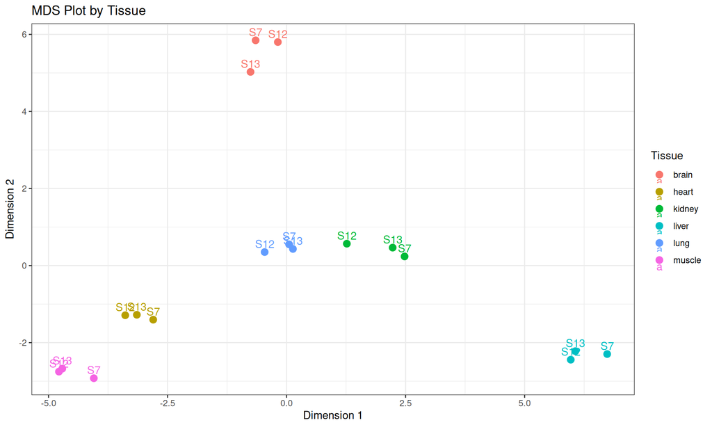

```r
mds <- plotMDS(dge, plot = FALSE)

# Plot MDS
ggplot(data.frame(
    x = mds$x,
    y = mds$y,
    Tissue = metadata$Tissue,
    Donor = metadata$Donor
), aes(x, y, color = Tissue, label = Donor)) +
    geom_point(size = 3) +
    geom_text(vjust = -0.5) +
    theme_bw() +
    labs(title = "MDS Plot by Tissue", x = "Dimension 1", y = "Dimension 2")
```

**What we see:** Tissues cluster nicely by type, which is what we’d expect. Brain samples are quite different from everything else, and muscle and liver also form their own distinct groups.

# 5. Differential Expression Analysis

In this section, we will perform differential expression analysis to identify genes that are significantly differentially expressed between liver and brain tissues. We will use the `exactTest` function from edgeR to perform this analysis.

```r
# Select liver and brain samples for differential expression analysis
selected_tissues <- c("liver", "brain")
selected_samples <- dge$samples$Tissue %in% selected_tissues
dge_selected <- dge[, selected_samples]
dge_selected$samples$group <- factor(dge_selected$samples$Tissue)

# Estimate dispersion
dge_selected <- estimateCommonDisp(dge_selected) # Estimate common dispersion across all genes
print(dge_selected$common.dispersion)
```

```
## [1] 0.2844287
```

```r
dge_selected <- estimateTagwiseDisp(dge_selected) # Estimate tagwise dispersion for each gene
print(head(dge_selected$tagwise.dispersion))
```

```
## [1] 0.1478447 0.1280367 0.2901868 0.1477545 0.1694573 0.4486430
```

```r
# Perform exact test for differential expression
et <- exactTest(dge_selected)

head(et$table)
```

```
##               logFC    logCPM       PValue
## 7SK      -0.4508437  8.297003 3.237447e-01
## A1BG      9.6272256  9.765880 4.860164e-55
## A1BG-AS1 -3.9022521  1.702303 2.184505e-07
## A1CF     13.3819330  9.203760 1.899400e-66
## A2M       4.0801030 10.551340 1.603586e-13
## A2M-AS1  -1.4369354  0.937513 8.716504e-02
```

# 6 Top Differentially Expressed Genes (DEGs)

In this section, we will extract the top differentially expressed genes (DEGs) from the results of the exact test. We will also create a volcano plot to visualize the results.

```r
top_genes <- topTags(et, n = Inf) # Get all top tags

head(top_genes$table)
```

```
##              logFC   logCPM       PValue          FDR
## CYP2A6    14.45059 9.655861 5.416217e-80 1.118611e-75
## CYP2C9    14.66348 9.872998 1.026764e-70 1.060288e-66
## ACSM2A    14.39719 8.011960 6.892504e-68 4.745029e-64
## SERPINA10 14.86083 7.992368 7.502782e-67 3.873874e-63
## CPN2      15.14926 7.548840 1.846989e-66 6.538050e-63
## A1CF      13.38193 9.203760 1.899400e-66 6.538050e-63
```

```r
sig_genes <- top_genes$table[top_genes$table$FDR < 0.01, ] # Filter for significant genes with FDR < 0.01

head(sig_genes)
```

```
##              logFC   logCPM       PValue          FDR
## CYP2A6    14.45059 9.655861 5.416217e-80 1.118611e-75
## CYP2C9    14.66348 9.872998 1.026764e-70 1.060288e-66
## ACSM2A    14.39719 8.011960 6.892504e-68 4.745029e-64
## SERPINA10 14.86083 7.992368 7.502782e-67 3.873874e-63
## CPN2      15.14926 7.548840 1.846989e-66 6.538050e-63
## A1CF      13.38193 9.203760 1.899400e-66 6.538050e-63
```

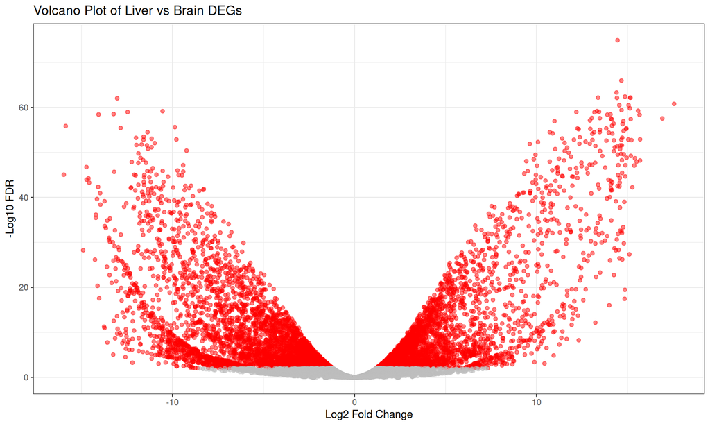

```r
# Create volcano plot
ggplot(top_genes$table, aes(x = logFC, y = -log10(FDR))) +
    geom_point(aes(color = FDR < 0.01), alpha = 0.5) +
    scale_color_manual(values = c("grey", "red")) +
    theme_bw() +
    labs(title = "Volcano Plot of Liver vs Brain DEGs", x = "Log2 Fold Change", y = "-Log10 FDR") +
    theme(legend.position = "none")
```

# 7 Expression Categories

In this section, we will classify the genes into different categories based on their expression patterns. We will create a boxplot to visualize the distribution of log fold changes (logFC) for each category.

```r
gene_classes <- data.frame(top_genes$table) # Create a data frame with top genes
print(head(gene_classes))
```

```
##              logFC   logCPM       PValue          FDR
## CYP2A6    14.45059 9.655861 5.416217e-80 1.118611e-75
## CYP2C9    14.66348 9.872998 1.026764e-70 1.060288e-66
## ACSM2A    14.39719 8.011960 6.892504e-68 4.745029e-64
## SERPINA10 14.86083 7.992368 7.502782e-67 3.873874e-63
## CPN2      15.14926 7.548840 1.846989e-66 6.538050e-63
## A1CF      13.38193 9.203760 1.899400e-66 6.538050e-63
```

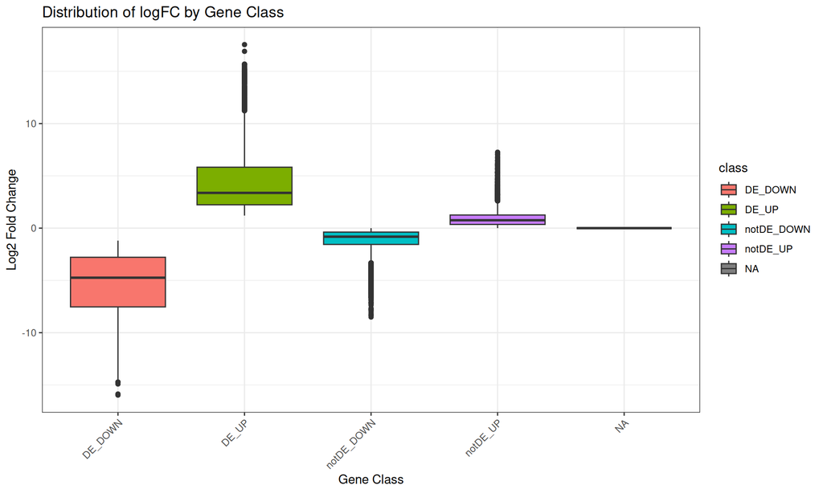

```r
# Classify genes based on FDR and logFC
gene_classes$class <- ifelse(gene_classes$FDR <= 0.01 & gene_classes$logFC > 0, "DE_UP",
    ifelse(gene_classes$FDR <= 0.01 & gene_classes$logFC < 0, "DE_DOWN",
        ifelse(gene_classes$FDR > 0.01 & gene_classes$logFC > 0, "notDE_UP",
            ifelse(gene_classes$FDR > 0.01 & gene_classes$logFC < 0, "notDE_DOWN", NA)
        )
    )
)

# Create boxplot
ggplot(gene_classes, aes(x = class, y = logFC, fill = class)) +
    geom_boxplot() +
    theme_bw() +
    ggtitle("Distribution of logFC by Gene Class") +
    xlab("Gene Class") +
    ylab("Log2 Fold Change") +
    theme(axis.text.x = element_text(angle = 45, hjust = 1))
```

**What we see:** The significantly different genes (DE_UP and DE_DOWN) are clearly separated from the non-significant ones, which gives us confidence in our results.

# TRACK_1

# TRACK 1.1 Individual Expression Profiles

In this section, we will analyze individual-specific and individual-elevated expression patterns across donors. We will calculate counts per million (CPM) values and classify genes based on their expression patterns.

```r
# Calculate CPM values
cpm_values <- cpm(dge, log = FALSE)

head(dge$counts) # Before normalization
```

```
##          liver_S7 brain_S7 muscle_S7 heart_S7 kidney_S7 lung_S7 liver_S12
## 7SK          6211     7516      5485     7338     22610   17680   5144.00
## A1BG        51808       73        14       27        46     121  29836.00
## A1BG-AS1        9      193         4       20        31     129      6.00
## A1CF        36445        2        19       10      4193       0  20126.00
## A2M         90484     9743      8951    32012     22370  305920  30940.98
## A2M-AS1        11       68        27      169        34      85     17.00
##          brain_S12 muscle_S12 heart_S12 kidney_S12 lung_S12 liver_S13 brain_S13
## 7SK          24682       4877      7683      24804    14654      6647     23302
## A1BG           124         10        12         30       65     35922       129
## A1BG-AS1       368          3        14         35      146        12       318
## A1CF             7          0         2        152        2     23024         7
## A2M           6095       6627     29156      34365   214209     74382      7615
## A2M-AS1         66         58        36         67       46        41       289
##          muscle_S13 heart_S13 kidney_S13 lung_S13
## 7SK            8394      4743      14312    20097
## A1BG             27         9         33       95
## A1BG-AS1          2        17         25      117
## A1CF              1         0       4788        2
## A2M           11636     32589      33568   147556
## A2M-AS1         111       120         54       47
```

```r
head(cpm_values) # After normalization
```

```
##              liver_S7     brain_S7   muscle_S7     heart_S7   kidney_S7
## 7SK       274.4056840 191.89995315 311.3134940  338.3915417 630.8145114
## A1BG     2288.9083366   1.86385000   0.7946014    1.2451038   1.2833909
## A1BG-AS1    0.3976254   4.92771301   0.2270290    0.9222991   0.8648938
## A1CF     1610.1618346   0.05106438   1.0783877    0.4611496 116.9838676
## A2M      3997.6370817 248.76014416 508.0341084 1476.2319478 624.1185590
## A2M-AS1     0.4859866   1.73618904   1.5324456    7.7934274   0.9485933
##              lung_S7    liver_S12   brain_S12 muscle_S12    heart_S12
## 7SK       376.285794  260.1647495 494.5448575 303.227491  552.3916458
## A1BG        2.575259 1508.9960080   2.4845459   0.621750    0.8627749
## A1BG-AS1    2.745524    0.3034581   7.3734911   0.186525    1.0065707
## A1CF        0.000000 1017.8996399   0.1402566   0.000000    0.1437958
## A2M      6510.936094 1564.8818643 122.1234465 412.033747 2096.2554764
## A2M-AS1     1.809066    0.8597980   1.3224196   3.606150    2.5883248
##           kidney_S12    lung_S12    liver_S13   brain_S13   muscle_S13
## 7SK      631.7854865  443.803705  262.5867075 403.1259472 356.10156957
## A1BG       0.7641334    1.968557 1419.0822487   2.2317075   1.14543035
## A1BG-AS1   0.8914890    4.421683    0.4740545   5.5014184   0.08484669
## A1CF       3.8716092    0.060571  909.5526333   0.1211004   0.04242335
## A2M      875.3147977 6487.426491 2938.4270314 131.7399403 493.63805856
## A2M-AS1    1.7065646    1.393133    1.6196863   4.9997167   4.70899145
##             heart_S13  kidney_S13     lung_S13
## 7SK       236.7387797 355.6186526  469.3061046
## A1BG        0.4492197   0.8199703    2.2184445
## A1BG-AS1    0.8485261   0.6211897    2.7321896
## A1CF        0.0000000 118.9702424    0.0467041
## A2M      1626.6245186 834.0837710 3445.7347645
## A2M-AS1     5.9895959   1.3417697    1.0975462
```

```r
# Calculate donor averages
donor_averages <- list() # Initialize list to store averages

for (donor in unique(metadata$Donor)) {
    donor_samples <- metadata$Donor == donor # Get samples for the donor
    donor_averages[[donor]] <- rowMeans(cpm_values[, donor_samples], na.rm = TRUE) # Calculate average CPM for each gene across samples of the same donor
    print("")
    print(donor)
    print(head(donor_averages[[donor]]))
}
```

```
## [1] ""
## [1] "S7"
##         7SK        A1BG    A1BG-AS1        A1CF         A2M     A2M-AS1
##  353.851830  382.778424    1.680847  288.122717 2227.619656    2.384285
## [1] ""
## [1] "S12"
##         7SK        A1BG    A1BG-AS1        A1CF         A2M     A2M-AS1
##  447.652989  252.616295    2.363869  170.352645 1926.339304    1.912732
## [1] ""
## [1] "S13"
##         7SK        A1BG    A1BG-AS1        A1CF         A2M     A2M-AS1
##  347.246294  237.657837    1.710371  171.455517 1578.374681    3.292884
```

```r
# Convert to data frame
avg_expr <- data.frame(
    S7 = donor_averages$S7,
    S12 = donor_averages$S12,
    S13 = donor_averages$S13
)

print(head(avg_expr))
```

```
##                   S7         S12         S13
## 7SK       353.851830  447.652989  347.246294
## A1BG      382.778424  252.616295  237.657837
## A1BG-AS1    1.680847    2.363869    1.710371
## A1CF      288.122717  170.352645  171.455517
## A2M      2227.619656 1926.339304 1578.374681
## A2M-AS1     2.384285    1.912732    3.292884
```

```r
# Classify genes
classify_expression <- function(row) {
    max_value <- max(row) # Get maximum value in the row
    max_donor <- names(row)[which.max(row)] # Get donor with maximum value
    other_values <- row[row != max_value] # Get other values excluding the maximum
    average_others <- mean(other_values)

    if (max_value >= 4 * max(other_values)) {
        return(paste("individual_specific", max_donor, sep = "_"))
    } else if (max_value >= 2 * average_others) {
        return(paste("individual_elevated", max_donor, sep = "_"))
    } else {
        return("not_elevated")
    }
}

expression_classes <- apply(avg_expr, 1, classify_expression) # Classify each gene based on its expression pattern

print(head(expression_classes, n = 20))
```

```
##                      7SK                     A1BG                 A1BG-AS1
##           "not_elevated"           "not_elevated"           "not_elevated"
##                     A1CF                      A2M                  A2M-AS1
##           "not_elevated"           "not_elevated"           "not_elevated"
##                    A2ML1                   A4GALT                     AAAS
##           "not_elevated"           "not_elevated"           "not_elevated"
##                     AACS                   AACSP1                    AADAC
##           "not_elevated"           "not_elevated" "individual_elevated_S7"
##                    AADAT                    AAED1                    AAGAB
##           "not_elevated"           "not_elevated"           "not_elevated"
##                     AAK1                    AAMDC                     AAMP
##           "not_elevated"           "not_elevated"           "not_elevated"
##                     AAR2                     AARD
##           "not_elevated"           "not_elevated"
```

```r
# Count individual specific genes
individual_specific_counts <- table(expression_classes[grep("individual_specific_", expression_classes)])
print(individual_specific_counts)
```

```
##
## individual_specific_S12 individual_specific_S13  individual_specific_S7
##                     138                     224                     136
```

```r
# Count individual elevated genes
individual_elevated_counts <- table(expression_classes[grep("individual_elevated_", expression_classes)])
print(individual_elevated_counts)
```

```
##
## individual_elevated_S12 individual_elevated_S13  individual_elevated_S7
##                    1361                     602                     836
```

# TRACK 1.2 Expression Patterns visualizations

```r
# Extract gene names for individual-specific and individual-elevated genes
specific_genes <- names(expression_classes[grep("individual_specific_", expression_classes)])
elevated_genes <- names(expression_classes[grep("individual_elevated_", expression_classes)])

# Filter for significant genes only between liver and brain
individual_specific_degs <- specific_genes[specific_genes %in% rownames(sig_genes)]
individual_elevated_degs <- elevated_genes[elevated_genes %in% rownames(sig_genes)]

head(individual_specific_degs)
```

```
## [1] "ADAMTS18" "AK024535" "AK054708" "AK054905" "AK091593" "AK094325"
```

```r
head(individual_elevated_degs)
```

```
## [1] "AADAC"    "AB074160" "AB429224" "ABAT"     "ABCA13"   "ABCC12"
```

```r
# Count the number of individual-specific and individual-elevated DEGs
n_individual_specific_degs <- length(individual_specific_degs)
n_individual_elevated_degs <- length(individual_elevated_degs)

print(paste("Individual-specific DEGs:", n_individual_specific_degs))
```

```
## [1] "Individual-specific DEGs: 151"
```

```r
print(paste("Individual-elevated DEGs:", n_individual_elevated_degs))
```

```
## [1] "Individual-elevated DEGs: 1280"
```

# TRACK 1.3 Individual Gene Analysis

```
## Average expression:
##           S7     S12      S13
## 7SK 353.8518 447.653 347.2463
## Class: not_elevated
```

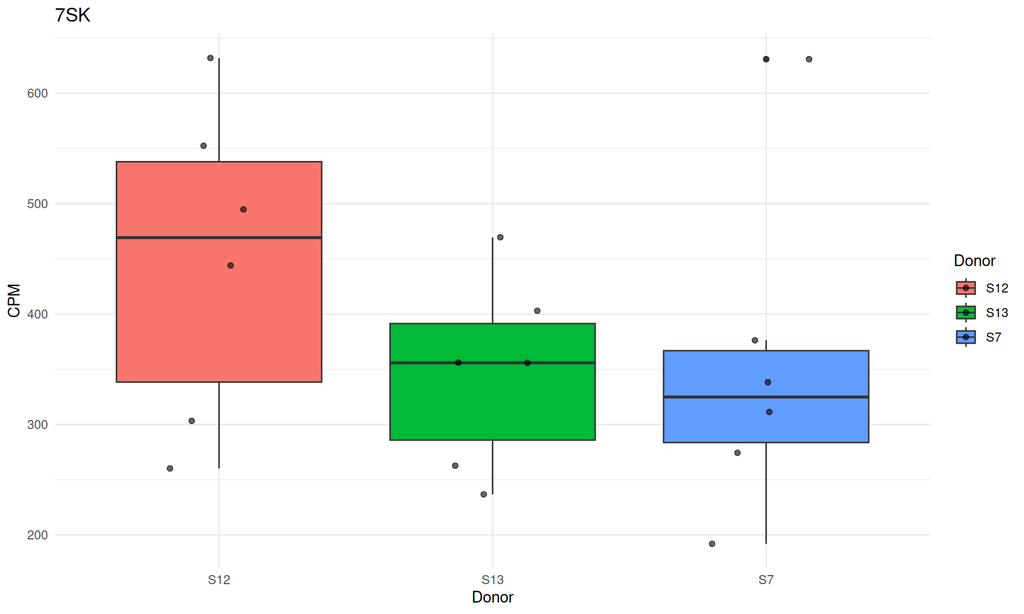

```r
analyze_gene <- function(gene_name, cpm_values, metadata, expression_classes, avg_expr, plot_type = "barplot") {

# Takes all info for a single gene
    expr_values <- cpm_values[gene_name, ]
    avg_by_donor <- avg_expr[gene_name, ]

# Print average expression and class
    cat("Average expression:\n")
    print(avg_by_donor)
    cat("Class:", expression_classes[gene_name], "\n")

 # Create a barplot or boxplot for the gene
    donor <- names(avg_by_donor) # Take and assign donor names

    plot <- if (plot_type == "barplot") {
        ggplot(data.frame(Donor = donor, Avg = as.numeric(avg_by_donor)),
               aes(x = Donor, y = Avg, fill = Donor)) +
            geom_bar(stat = "identity") +
            labs(title = gene_name, y = "Average CPM") +
            theme_minimal()
    } else {
        ggplot(data.frame(Expression = expr_values, Donor = metadata$Donor),
               aes(x = Donor, y = Expression, fill = Donor)) +
            geom_boxplot() +
            geom_jitter(width = 0.2, alpha = 0.6) +
            labs(title = gene_name, y = "CPM") +
            theme_minimal()
    }

    print(plot)
}

analyze_gene("7SK", cpm_values, metadata, expression_classes, avg_expr, "boxplot")
```

```
## Average expression:
##           S7     S12      S13
## 7SK 353.8518 447.653 347.2463
## Class: not_elevated
```

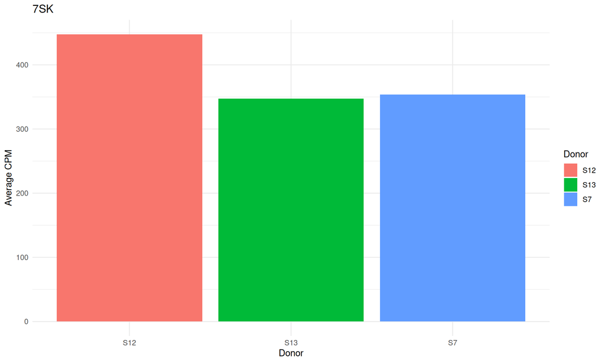

```r
analyze_gene("7SK", cpm_values, metadata, expression_classes, avg_expr, "barplot")
```

# Overall Summary

In this RNA-Seq analysis, we successfully identified differentially expressed genes between liver and brain tissues, classified genes based on their expression patterns across individual donors, and visualized these patterns. We found that some genes were uniquely expressed in specific individuals, while others showed elevated expression levels.